# PROJECT - IST 707 - Melbourne Housing Market

Tushar Mundodu

December 17, 2018

```
## [1] 25000
```

# Importing dataset from Kaggle

Link: https://www.kaggle.com/anthonypino/melbourne-housing-market

```r
mel<- read.csv("C:/Users/Tushar/Desktop/Courses/3rd SEM/IST 707/Project/MHP.csv",header = T, stringsAsFactors = FALSE)
summary(mel)
```

```
##     Suburb              Rooms            Type              Method
##  Length:27246       Min.   : 1.000   Length:27246       Length:27246
##  Class :character   1st Qu.: 2.000   Class :character   Class :character
##  Mode  :character   Median : 3.000   Mode  :character   Mode  :character
##                     Mean   : 2.992
##                     3rd Qu.: 4.000
##                     Max.   :16.000
##
##     Agent            Date_Sold           Distance
##  Length:27246       Length:27246       Length:27246
##  Class :character   Class :character   Class :character
##  Mode  :character   Mode  :character   Mode  :character
##
##
##
##
##  Postal_Code           Bedrooms        Bathrooms        Carspots
##  Length:27246       Min.   : 0.000   Min.   :0.000   Min.   : 0.000
##  Class :character   1st Qu.: 2.000   1st Qu.:1.000   1st Qu.: 1.000
##  Mode  :character   Median : 3.000   Median :1.000   Median : 2.000
##                     Mean   : 3.046   Mean   :1.592   Mean   : 1.715
##                     3rd Qu.: 4.000   3rd Qu.:2.000   3rd Qu.: 2.000
##                     Max.   :20.000   Max.   :9.000   Max.   :18.000
##                     NA's   :6441     NA's   :6447    NA's   :6824
##     Landsize        Building_Area       Year_Built
##  Min.   :     0.0   Min.   :    0.0   Min.   :1196
##  1st Qu.:   219.0   1st Qu.:  100.0   1st Qu.:1950
##  Median :   512.0   Median :  133.0   Median :1970
##  Mean   :   593.5   Mean   :  156.8   Mean   :1967
##  3rd Qu.:   664.0   3rd Qu.:  181.8   3rd Qu.:2000
##  Max.   :433014.0   Max.   :44515.0   Max.   :2018
##  NA's   :9265       NA's   :16591     NA's   :15163
##  Govt_City_Council_Area   Lattitude        Longtitude
##  Length:27246           Min.   :-38.19   Min.   :144.4
##  Class :character       1st Qu.:-37.86   1st Qu.:144.9
##  Mode  :character       Median :-37.80   Median :145.0
##                         Mean   :-37.81   Mean   :145.0
##                         3rd Qu.:-37.75   3rd Qu.:145.1
##                         Max.   :-37.40   Max.   :145.5
##                         NA's   :6254     NA's   :6254
##  Metropolitan_Region Property_Count         Price
##  Length:27246        Length:27246       Min.   :   85000
##  Class :character    Class :character   1st Qu.:  635000
##  Mode  :character    Mode  :character   Median :  870000
##                                         Mean   : 1050172
##                                         3rd Qu.: 1295000
##                                         Max.   :11200000
##
```

```r
df_mel<- data.frame(mel)
head(df_mel,2)
```

```
##       Suburb Rooms Type Method  Agent Date_Sold Distance Postal_Code
## 1 Abbotsford     2    h   Sold Biggin 3/12/2016      2.5        3067
## 2 Abbotsford     2    h   Sold Biggin  4/2/2016      2.5        3067
##   Bedrooms Bathrooms Carspots Landsize Building_Area Year_Built
## 1        2         1        1      202            NA         NA
## 2        2         1        0      156            79       1900
##   Govt_City_Council_Area Lattitude Longtitude Metropolitan_Region
## 1                Yarra    -37.7996   144.9984           Northern
## 2                Yarra    -37.8079   144.9934           Northern
##   Property_Count   Price
## 1           4019 1480000
## 2           4019 1035000
```

# Data Pre-processing

Checking for data incompleteness,

```r
s1<-sum(!complete.cases(df_mel))
print(paste0("Missing values before imputation : ",s1))
```

```
## [1] "Missing values before imputation : 18360"
```

Imputing missing values using Bootstrapping and RMM (HMisc): Hmisc is a multiple purpose package useful for data analysis, high - level graphics, imputing missing values, advanced table making, model fitting & diagnostics (linear regression, logistic regression & cox regression) etc. Amidst, the wide range of functions contained in this package, it offers 2 powerful functions for imputing missing values.

aregImpute() allows mean imputation using additive regression, bootstrapping, and predictive mean matching.

In bootstrapping, different bootstrap resamples are used for each of multiple imputations. Then, a flexible additive model (non parametric regression method) is fitted on samples taken with replacements from original data and missing values (acts as dependent variable) are predicted using non-missing values (independent variable).

Then, it uses predictive mean matching (default) to impute missing values. Predictive mean matching works well for continuous and categorical (binary & multi-level) without the need for computing residuals and maximum likelihood fit.

```r
impute_arg <- aregImpute(~ Rooms + Bedrooms + Bathrooms + Carspots  + Landsize + Building_Area + Year_Built + Lattitude + Longtitude, data = df_mel, n.impute = 5, nk=0,tlinear = F,B=75)
```

```
## Iteration 1
Iteration 2
Iteration 3
Iteration 4
Iteration 5
Iteration 6
Iteration 7
Iteration 8
```

```r
impute_arg
```

```
##
## Multiple Imputation using Bootstrap and PMM
##
## aregImpute(formula = ~Rooms + Bedrooms + Bathrooms + Carspots +
##     Landsize + Building_Area + Year_Built + Lattitude + Longtitude,
##     data = df_mel, n.impute = 5, nk = 0, tlinear = F, B = 75)
##
## n: 27246     p: 9    Imputations: 5      nk: 0
##
## Number of NAs:
##         Rooms      Bedrooms     Bathrooms      Carspots      Landsize
##             0          6441          6447          6824          9265
## Building_Area    Year_Built     Lattitude    Longtitude
##         16591         15163          6254          6254
##
##               type d.f.
## Rooms            l    1
## Bedrooms         l    1
## Bathrooms        l    1
## Carspots         l    1
## Landsize         l    1
## Building_Area    l    1
## Year_Built       l    1
## Lattitude        l    1
## Longtitude       l    1
##
## R-squares for Predicting Non-Missing Values for Each Variable
## Using Last Imputations of Predictors
##      Bedrooms     Bathrooms      Carspots      Landsize Building_Area
##         0.895         0.420         0.188         0.039         0.204
##    Year_Built     Lattitude    Longtitude
##         0.088         0.135         0.128
```

Appending imputed values

```r
imputed <-impute.transcan(impute_arg, data=df_mel, imputation=1, list.out=TRUE, pr=FALSE, check=FALSE)
melb <- as.data.frame(do.call(cbind,imputed))
```

Cross-checking for missing values on final data frame

```r
mhp_1 <- cbind.data.frame(df_mel$Suburb,melb$Rooms,melb$Bedrooms,df_mel$Type,df_mel$Method,df_mel$Agent,df_mel$Date_Sold,df_mel$Distance,df_mel$Postal_Code,melb$Bathrooms,melb$Carspots,melb$Landsize,melb$Building_Area,melb$Year_Built,df_mel$Govt_City_Council_Area,df_mel$Metropolitan_Region,df_mel$Property_Count,melb$Lattitude,melb$Longtitude,df_mel$Price)

colnames(mhp_1)<-c("Suburb","Rooms","Bedrooms","Type","Method","Agent","Date_Sold","Distance","Postal_Code","Bathrooms","Carspots","Landsize","Building_Area","Year_Built","Govt_City_Council_Area","Metropolitan_Region","Property_Count","Lattitude","Longitude","Price")
#View(mhp_1)

s2<-sum(!complete.cases(mhp_1))
print(paste0("Missing values after imputation : ",s2))
```

```
## [1] "Missing values after imputation : 0"
```

Correlation between dependent variables;

```r
cor_data<- as.data.frame(mhp_1[,c(2,3,8,10:14,17,20)])
str(cor_data)
```

```
## 'data.frame':    27246 obs. of  10 variables:
##  $ Rooms         : num  2 2 3 3 4 2 3 2 3 2 ...
##  $ Bedrooms      : num  2 2 3 3 3 2 4 2 3 2 ...
##  $ Distance      : Factor w/ 214 levels "#N/A","0","0.7",..: 82 82 82 82 82 82 82 82 82 82 ...
##  $ Bathrooms     : num  1 1 2 2 1 1 2 1 1 1 ...
##  $ Carspots      : num  1 0 0 1 2 0 0 2 2 1 ...
##  $ Landsize      : num  202 156 134 94 120 181 245 256 195 229 ...
##  $ Building_Area : num  100 79 150 110 142 92 210 107 144 80 ...
##  $ Year_Built    : num  1980 1900 1900 1970 2014 ...
##  $ Property_Count: Factor w/ 337 levels "#N/A","1008",..: 186 186 186 186 186 186 186 186 186 186 ...
##  $ Price         : num  1480000 1035000 1465000 850000 1600000 ...
```

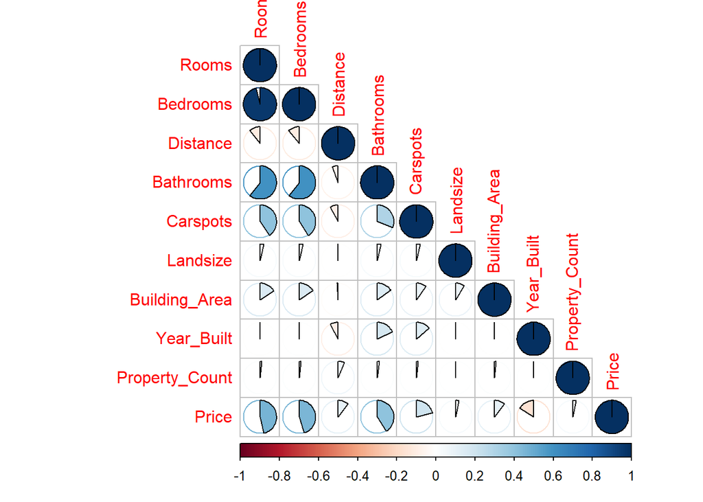

```r
cor_data$Distance<- as.numeric(cor_data$Distance)
cor_data$Property_Count<- as.numeric(cor_data$Property_Count)
corrplot(cor(as.matrix(cor_data)), method = "pie", type="lower")
```

*Bedrooms are highly correlated with rooms and bathrooms, so they are not considered for the furhter analysis. Adding bedrooms would give a biased result in most modelling. Also, Postal code/zipcode is not a numerical, but a categorical discrete variable.*

Final data frame, and data frame for modelling

```r
mhp_df<- as.data.frame(mhp_1[,-c(3)])
mhp_mod<- as.data.frame(mhp_df)
head(mhp_mod,10)
```

```
##        Suburb Rooms Type     Method  Agent Date_Sold Distance Postal_Code
## 1  Abbotsford     2    h       Sold Biggin 3/12/2016      2.5        3067
## 2  Abbotsford     2    h       Sold Biggin  4/2/2016      2.5        3067
## 3  Abbotsford     3    h  Passed in Biggin  4/3/2017      2.5        3067
## 4  Abbotsford     3    h Vendor bid Biggin  4/3/2017      2.5        3067
## 5  Abbotsford     4    h       Sold Nelson  4/6/2016      2.5        3067
## 6  Abbotsford     2    t       Sold Jellis  7/5/2016      2.5        3067
## 7  Abbotsford     3    u       Sold Nelson  7/5/2016      2.5        3067
## 8  Abbotsford     2    u Sold prior Nelson 8/10/2016      2.5        3067
## 9  Abbotsford     3    u Sold prior Jellis 8/10/2016      2.5        3067
## 10 Abbotsford     2    u Vendor bid Jellis 8/10/2016      2.5        3067
##    Bathrooms Carspots Landsize Building_Area Year_Built
## 1          1        1      202           100       1980
## 2          1        0      156            79       1900
## 3          2        0      134           150       1900
```

[output cut: 29 more lines]

# About the data:

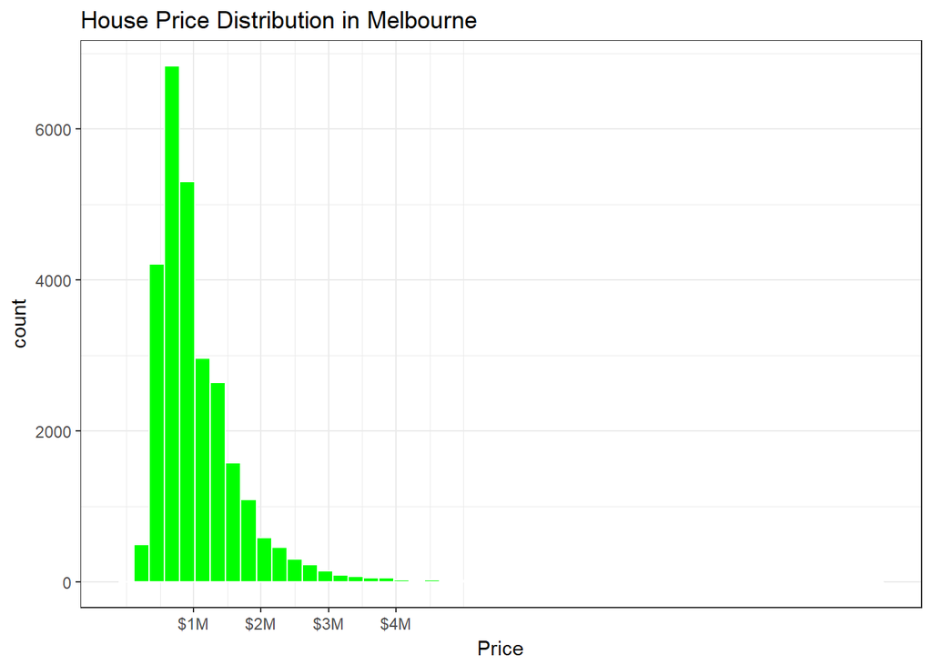

```r
ggplot(mhp_mod, aes(Price))+
  geom_histogram(bins = 50,color = "white", fill = "Green")+
  scale_x_continuous(breaks = c(1000000,2000000,3000000,4000000),
                     labels = c("$1M","$2M","$3M","$4M"))+
  ggtitle("House Price Distribution in Melbourne")+theme_bw()
```

The target variable is heavily **right skewed** implying that the mean of the housing prices > median price. Mean of Melbourne housing price is **$1,050,172 (Australian Dollars).**

# Real-world organizational/business application:

**Melbourne is currently experiencing a housing bubble (some experts say it may burst soon). According to Deloitte Access Economics’ latest business outlook, housing prices are falling by over $1000/week. This is mostly because banks are raising their interest rates, less FDI on real estate in Melbourne, and banks have become more cautious with giving away loans (Wood, ABC News Breakfast, 2018).**

# Modelling

## Modelling 1: XGBoost

XGBoost is an implementation of gradient boosted decision trees designed for speed and performance. XGBoost stands for eXtreme Gradient Boosting. It dominates structured or tabular datasets on classification and regression predictive modeling problems.

Splitting the dataset into training and testing in 7:3 ratio Running XGBoost

```r
transformdata<- as.data.frame(mhp_mod[,c(1:5,7:16,19)])

features <- colnames(transformdata)

for (f in features) {
  if ((class(transformdata[[f]])=="factor") || (class(transformdata[[f]])=="character")) {
    levels <- unique(transformdata[[f]])
    transformdata[[f]] <- as.numeric(factor(transformdata[[f]], levels=levels))
  }
}

train_size_xg = floor(0.7*nrow(transformdata))
test_size_xg = floor(0.3*nrow(transformdata))

set.seed(6093)   # set seed to ensure you always have same random numbers generated
train_ind_xg = sample(seq_len(nrow(transformdata)),size = train_size_xg)
test_ind_xg = sample(seq_len(nrow(transformdata)),size = test_size_xg)

training_xg<- transformdata[train_ind_xg,]
testing_xg<- transformdata[test_ind_xg,]


fitControl <- trainControl(method="none")
xgbGrid <- expand.grid(nrounds = 500,
                       max_depth = 3,
                       eta = .05,
                       gamma = 0,
                       colsample_bytree = .8,
                       min_child_weight = 1,
                       subsample = 1)


set.seed(4461)
start_time_xg <- Sys.time()
xg_melXGB = train(Price ~. , data = transformdata,
                   method = "xgbTree",trControl = fitControl,
                   tuneGrid = xgbGrid,na.action = na.pass,metric="RMSE")
end_time_xg <- Sys.time()
diff_xg<- end_time_xg-start_time_xg
```

Determining rank variable based on relative importance of the variables

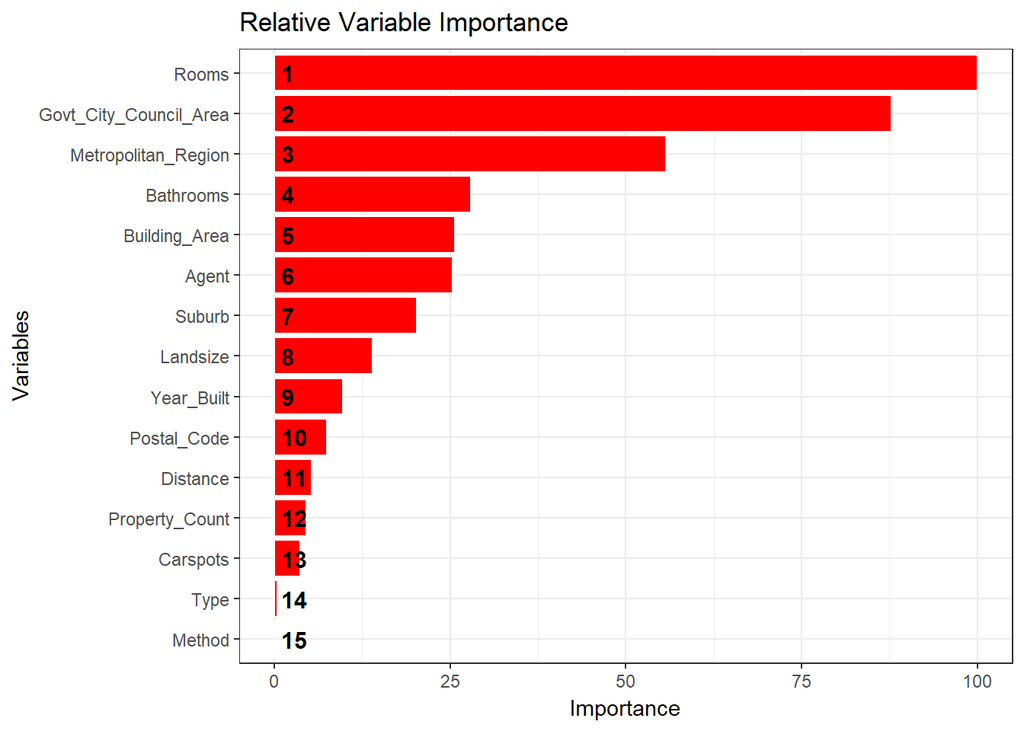

```r
importance = varImp(xg_melXGB)
varImportance <- data.frame(Variables = row.names(importance[[1]]),
                            Importance = round(importance[[1]]$Overall,2))

rankImportance <- varImportance %>%
  mutate(Rank = paste0(dense_rank(desc(Importance))))

rankImportancefull = rankImportance

ggplot(rankImportance, aes(x = reorder(Variables, Importance),
                           y = Importance)) +
  geom_bar(stat='identity',colour="white", fill = "Red") +
  geom_text(aes(x = Variables, y = 1, label = Rank),
            hjust=0, vjust=.5, size = 4, colour = 'black',
            fontface = 'bold') +
  labs(x = 'Variables', title = 'Relative Variable Importance') +
  coord_flip() +
  theme_bw()
```

As can be seen from the plot through feature engineering with XGBoost, **Rooms** were ranked the highest, while **type and method** the lowest.

Metropolitan region is one of the predominant factors determining the housing price distribution in Melbourne.

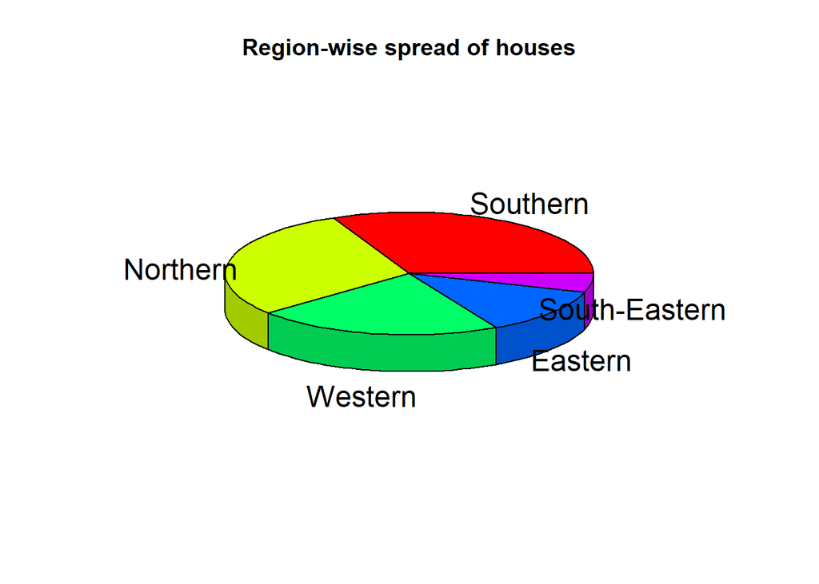

```r
Reg_type<- sqldf("select Metropolitan_Region,COUNT(*) AS 'Totals' FROM mhp_mod GROUP BY Metropolitan_Region ORDER BY Totals DESC LIMIT 5")
pie3D(Reg_type$Totals,labels=Reg_type$Metropolitan_Region,main="Region-wise spread of houses")
```

```r
head(Reg_type)
```

```
##   Metropolitan_Region Totals
## 1           Southern    8523
## 2           Northern    7864
## 3            Western    5815
## 4            Eastern    3272
## 5      South-Eastern    1341
```

```r
suburbData = mhp_mod %>% group_by(Suburb) %>%
  summarise(AvgPricePerSuburb = round(median(Price),0)) %>%
  arrange(desc(AvgPricePerSuburb))
suburbData$AvgPriceSuburb = scales::dollar(suburbData$AvgPricePerSuburb)
suburbData = suburbData[0:19,]
suburbData$AvgPricePerSuburb2 = scales::dollar(suburbData$AvgPricePerSuburb)

Suburbs = c(head(as.character(suburbData$Suburb),20))

SuburbsTop = mhp_df %>% filter(Suburb %in% Suburbs)
center_lon = median(SuburbsTop$Longitude)
center_lat = median(SuburbsTop$Lattitude)

leaflet(SuburbsTop) %>% addTiles() %>%
  addCircles(lng = ~Longitude, lat = ~Lattitude,radius = 3,
             color = c("red"))  %>% setView(lng=center_lon, lat=center_lat, zoom=12)
```

[interactive chart not shown]

## Modelling 2 : Association Rules

“Association rules or a-rules are if/then statements for discovering interesting relationships between seemingly unrelated data in a large databases or other information repository.”

I have used a-rules as a supervised learning purpose by forcing the target classification attribute on the RHS.

Selected numerical continuous and discrete variable that can be discretised to categorical ordinal

```r
ar_mel_df<- data.frame(mhp_mod[,c(2,7,9:13,16,19)])
summary(ar_mel_df)
```

```
##      Rooms           Distance       Bathrooms        Carspots
##  Min.   : 1.000   11.2   : 1112   Min.   :0.000   Min.   : 0.00
##  1st Qu.: 2.000   13.8   :  558   1st Qu.:1.000   1st Qu.: 1.00
##  Median : 3.000   10.5   :  526   Median :1.000   Median : 2.00
##  Mean   : 2.992   5.2    :  486   Mean   :1.565   Mean   : 1.68
##  3rd Qu.: 4.000   7.8    :  461   3rd Qu.:2.000   3rd Qu.: 2.00
##  Max.   :16.000   9.2    :  459   Max.   :9.000   Max.   :18.00
##                   (Other):23644
##     Landsize        Building_Area       Year_Built   Property_Count
##  Min.   :     0.0   Min.   :    0.0   Min.   :1196   21650  :  727
##  1st Qu.:   207.0   1st Qu.:  103.0   1st Qu.:1950   8870   :  609
##  Median :   498.0   Median :  131.0   Median :1970   10969  :  493
##  Mean   :   568.8   Mean   :  149.8   Mean   :1966   14949  :  439
##  3rd Qu.:   661.0   3rd Qu.:  174.0   3rd Qu.:1999   14577  :  415
##  Max.   :433014.0   Max.   :44515.0   Max.   :2018   11918  :  387
##                                                      (Other):24176
##      Price
##  Min.   :   85000
##  1st Qu.:  635000
##  Median :  870000
##  Mean   : 1050172
##  3rd Qu.: 1295000
##  Max.   :11200000
##
```

```r
str(ar_mel_df)
```

```
## 'data.frame':    27246 obs. of  9 variables:
##  $ Rooms         : num  2 2 3 3 4 2 3 2 3 2 ...
##  $ Distance      : Factor w/ 214 levels "#N/A","0","0.7",..: 82 82 82 82 82 82 82 82 82 82 ...
##  $ Bathrooms     : num  1 1 2 2 1 1 2 1 1 1 ...
##  $ Carspots      : num  1 0 0 1 2 0 0 2 2 1 ...
##  $ Landsize      : num  202 156 134 94 120 181 245 256 195 229 ...
##  $ Building_Area : num  100 79 150 110 142 92 210 107 144 80 ...
##  $ Year_Built    : num  1980 1900 1900 1970 2014 ...
##  $ Property_Count: Factor w/ 337 levels "#N/A","1008",..: 186 186 186 186 186 186 186 186 186 186 ...
##  $ Price         : num  1480000 1035000 1465000 850000 1600000 ...
```

Discretisation with equal splits

```r
ar_mel_df[[ "Rooms"]] <- ordered(cut(ar_mel_df[[ "Rooms"]], c(0,2,4,16)),labels = c("1/2 BHK", "3/4 BHK", ">4 BHK"))
ar_mel_df[["Bathrooms"]] <- ordered(cut(ar_mel_df[["Bathrooms"]],c(-1,1,2,9)),labels = c("0/1 bathroom","2 bathrooms",">2 bathrooms"))
ar_mel_df[["Carspots"]] <- ordered(cut(ar_mel_df[["Carspots"]],c(-1,1,2,18)),labels = c("0/1 carspot","2 carspots",">2 carspots"))
ar_mel_df[["Landsize"]] <- ordered(cut(ar_mel_df[["Landsize"]],c(-1,410,630,433014)),labels = c("small-sized","mid-sized","large-sized"))
ar_mel_df[["Building_Area"]] <- ordered(cut(ar_mel_df[["Building_Area"]],c(-1,125,165,44515)),labels = c("small","medium","large"))
ar_mel_df[["Year_Built"]] <- ordered(cut(ar_mel_df[["Year_Built"]],c(1195,1950,2000,2018)),labels = c("early 90s","late 90s","recent"))
ar_mel_df[["Price"]] <- ordered(cut(ar_mel_df[["Price"]],c(0,1050172,11300000)),labels = c("LOW","HIGH"))

#Converting distance to numeric (in miles)
ar_mel_df$Distance<- as.numeric(trimws(ar_mel_df$Distance))
ar_mel_df$Distance[[23052]]<-13.1

#Converting Property Count to numeric
ar_mel_df$Property_Count<- as.numeric(levels(ar_mel_df$Property_Count))[ar_mel_df$Property_Count]
ar_mel_df$Property_Count[[14441]]<-7570
ar_mel_df$Property_Count[[21055]]<-8920
ar_mel_df$Property_Count[[23052]]<-5070

#Discretising Distance & Property_Count
summary(ar_mel_df$Distance)
```

```
##    Min. 1st Qu.  Median    Mean 3rd Qu.    Max.
##    0.00    6.40   10.50   11.28   14.00   48.10
```

```r
summary(ar_mel_df$Property_Count)
```

```
##    Min. 1st Qu.  Median    Mean 3rd Qu.    Max.
##      83    4294    6567    7567   10412   21650
```

```r
ar_mel_df[["Distance"]] <- ordered(cut(ar_mel_df[["Distance"]],c(-1,5.30,7.80,100)),labels = c("Near","Not too far","Very far"))
ar_mel_df[["Property_Count"]] <- ordered(cut(ar_mel_df[["Property_Count"]],c(82,5900,9000,21660)),labels = c("Few","Moderate","Many"))

str(ar_mel_df)
```

```
## 'data.frame':    27246 obs. of  9 variables:
##  $ Rooms         : Ord.factor w/ 3 levels "1/2 BHK"<"3/4 BHK"<..: 1 1 2 2 2 1 2 1 2 1 ...
##  $ Distance      : Ord.factor w/ 3 levels "Near"<"Not too far"<..: 1 1 1 1 1 1 1 1 1 1 ...
##  $ Bathrooms     : Ord.factor w/ 3 levels "0/1 bathroom"<..: 1 1 2 2 1 1 2 1 1 1 ...
##  $ Carspots      : Ord.factor w/ 3 levels "0/1 carspot"<..: 1 1 1 1 2 1 1 2 2 1 ...
##  $ Landsize      : Ord.factor w/ 3 levels "small-sized"<..: 1 1 1 1 1 1 1 1 1 1 ...
##  $ Building_Area : Ord.factor w/ 3 levels "small"<"medium"<..: 1 1 2 1 2 1 3 1 2 1 ...
##  $ Year_Built    : Ord.factor w/ 3 levels "early 90s"<"late 90s"<..: 2 1 1 2 3 2 1 1 2 2 ...
##  $ Property_Count: Ord.factor w/ 3 levels "Few"<"Moderate"<..: 1 1 1 1 1 1 1 1 1 1 ...
##  $ Price         : Ord.factor w/ 2 levels "LOW"<"HIGH": 2 1 2 1 2 1 2 2 1 1 ...
```

```r
sum(!complete.cases(ar_mel_df))
```

```
## [1] 0
```

Merging other categorical variables to run apriori

```r
melb_cat<- cbind.data.frame(mhp_df[,1],ar_mel_df$Rooms,mhp_df[,c(3:5)],ar_mel_df[,c(2:7)],mhp_df[,c(8,15)],ar_mel_df[,c(8,9)])
colnames(melb_cat)<-c("Suburb","Rooms","Type","Method","Agent","Distance","Bathrooms","Carspots","Landsize","Building_Area","Year_Built","Postal_Code","Metropolitan_Region","Property_Count","Price")
```

Default setting

```r
rules_def <- apriori(melb_cat)
```

```
## Apriori
##
## Parameter specification:
##  confidence minval smax arem  aval originalSupport maxtime support minlen
##         0.8    0.1    1 none FALSE            TRUE       5     0.1      1
##  maxlen target   ext
##      10  rules FALSE
##
## Algorithmic control:
##  filter tree heap memopt load sort verbose
##     0.1 TRUE TRUE  FALSE TRUE    2    TRUE
##
## Absolute minimum support count: 2724
##
## set item appearances ...[0 item(s)] done [0.00s].
## set transactions ...[947 item(s), 27246 transaction(s)] done [0.03s].
## sorting and recoding items ... [36 item(s)] done [0.00s].
## creating transaction tree ... done [0.02s].
## checking subsets of size 1 2 3 4 5 6 done [0.05s].
## writing ... [480 rule(s)] done [0.00s].
## creating S4 object  ... done [0.00s].
```

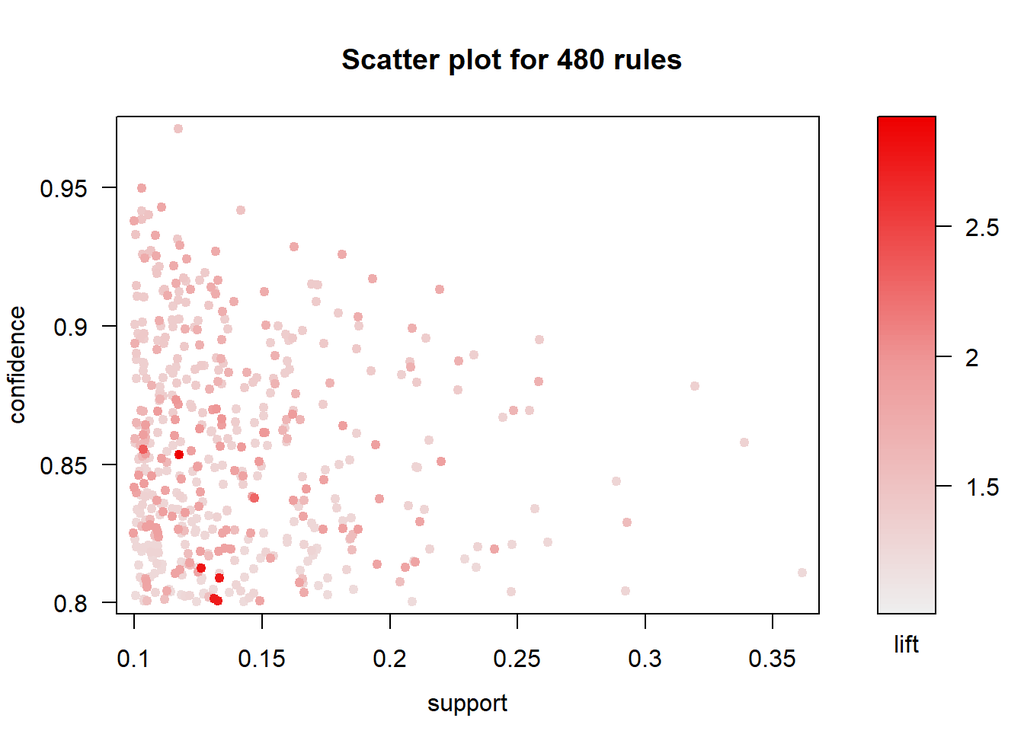

```r
rd<- sort(rules_def,by="lift",decreasing = T)
plot(rules_def, measure = c("support", "confidence"), shading = "lift")
```

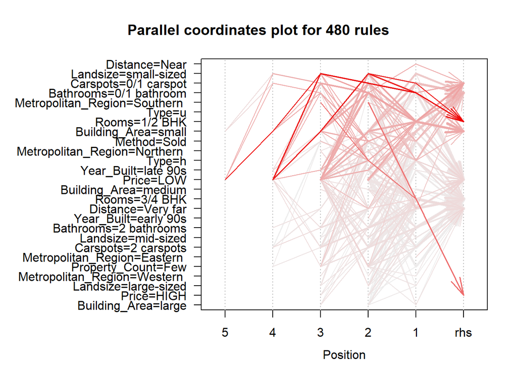

```r
plot(rules_def, method="paracoord", control=list(reorder=TRUE))
```

*Minimum support = 0.1*

Fine tuning the model by forcing classification variable “Price=High” on RHS

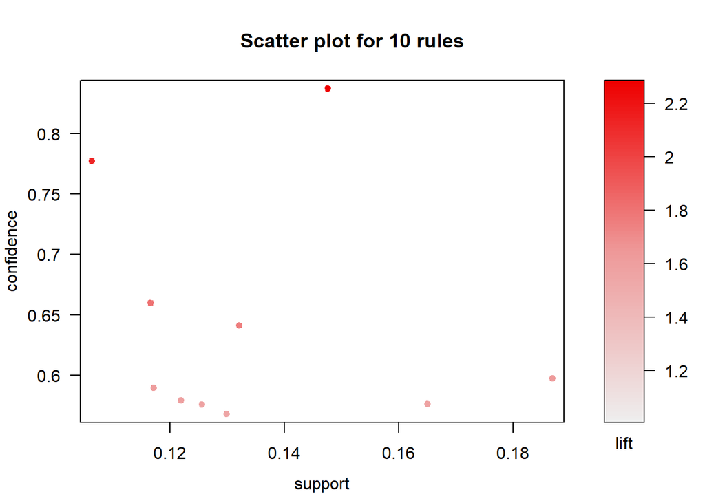

```r
rules_fine_H <- apriori(data = melb_cat, parameter = list(supp = 0.105, conf = 0.56, minlen = 1),appearance = list(default = "lhs",rhs = c("Price=HIGH")),control = list(verbose = F))
plot(rules_fine_H, measure = c("support", "confidence"), shading = "lift")
```

```r
rd_H<- sort(rules_fine_H,by="lift",decreasing = T)
#5 most interesting rules with highest lift value
inspect(head(rd_H,5))
```

```
##     lhs                                rhs            support confidence     lift count
## [1] {Rooms=3/4 BHK,
##      Metropolitan_Region=Southern } => {Price=HIGH} 0.1475446  0.8373256 2.280465  4020
## [2] {Carspots=2 carspots,
##      Metropolitan_Region=Southern } => {Price=HIGH} 0.1063275  0.7773008 2.116987  2897
## [3] {Distance=Very far,
##      Metropolitan_Region=Southern } => {Price=HIGH} 0.1165676  0.6598795 1.797189  3176
## [4] {Type=h,
##      Metropolitan_Region=Southern } => {Price=HIGH} 0.1320928  0.6411901 1.746288  3599
## [5] {Metropolitan_Region=Southern } => {Price=HIGH} 0.1868164  0.5972076 1.626501  5090
```

Fine tuning the model by forcing classification variable “Price=Low”" on RHS

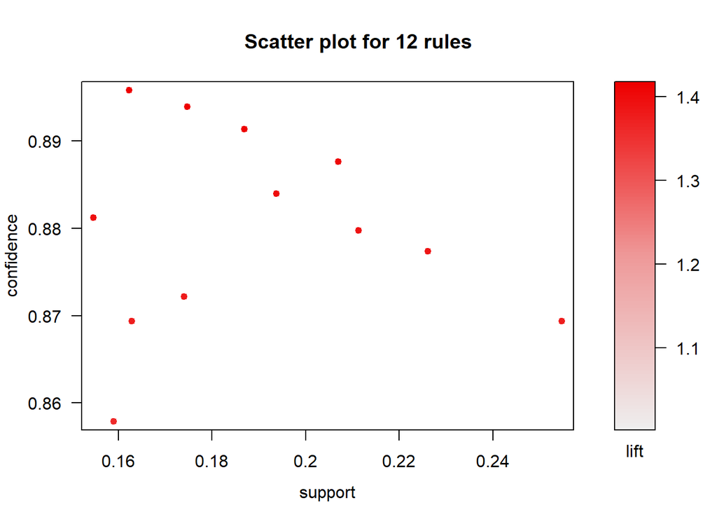

```r
rules_fine_L <- apriori(data = melb_cat, parameter = list(supp = 0.15, conf = 0.85, minlen = 1),appearance = list(default = "lhs",rhs = c("Price=LOW")),control = list(verbose = F))
plot(rules_fine_L, measure = c("support", "confidence"), shading = "lift")
```

```r
rd_L<- sort(rules_fine_L,by="lift",decreasing = T)
#5 most interesting rules with highest lift value
inspect(head(rd_L,5))
```

```
##     lhs                         rhs           support confidence     lift count
## [1] {Rooms=1/2 BHK,
##      Bathrooms=0/1 bathroom,
##      Carspots=0/1 carspot,
##      Building_Area=small}    => {Price=LOW} 0.1622624  0.8958460 1.415626  4421
## [2] {Rooms=1/2 BHK,
##      Carspots=0/1 carspot,
##      Building_Area=small}    => {Price=LOW} 0.1747412  0.8939166 1.412577  4761
## [3] {Rooms=1/2 BHK,
##      Bathrooms=0/1 bathroom,
##      Carspots=0/1 carspot}   => {Price=LOW} 0.1869632  0.8913386 1.408503  5094
## [4] {Rooms=1/2 BHK,
##      Carspots=0/1 carspot}   => {Price=LOW} 0.2070029  0.8876298 1.402643  5640
## [5] {Rooms=1/2 BHK,
##      Bathrooms=0/1 bathroom,
##      Building_Area=small}    => {Price=LOW} 0.1937532  0.8839585 1.396841  5279
```

## Modelling 3 : Random Forest

Random Forest is a flexible, easy to use supervised machine learning algorithm that produces, even without hyper-parameter tuning, a great result most of the time. It is also one of the most used algorithms, because of it’s simplicity and the fact that it can be used for both classification and regression tasks.It automatically measures relative importance of each feature used for prediction.

Running rf for classification on categorical variables as was used in a-rules

```r
dt_rf_df<- melb_cat[,c(2:4,6:11,13:15)]
```

Splitting the dataset into training and testing with 70% and 30%

```r
train_size_dt_rf = floor(0.7*nrow(dt_rf_df))
test_size_dt_rf = floor(0.3*nrow(dt_rf_df))

set.seed(3491)   # set seed to ensure you always have same random numbers generated
train_ind_dt_rf = sample(seq_len(nrow(dt_rf_df)),size = train_size_dt_rf)
test_ind_dt_rf = sample(seq_len(nrow(dt_rf_df)),size = test_size_dt_rf)

training_dt_rf<- dt_rf_df[train_ind_dt_rf,]
testing_dt_rf<- dt_rf_df[test_ind_dt_rf,]
```

Training the model and tuning using parameters:

*mtryStart* starting value of mtry

*ntreeTry* number of trees used at the tuning step

*stepFactor* at each iteration, mtry is inflated (or deflated) by this value

*improve* the (relative) improvement in OOB error must be by this much for the search to continue

```r
set.seed(9373)
start_time_rf <- Sys.time()
fit.rf <- randomForest(formula = Price ~ ., data = training_dt_rf, mtryStart = sqrt(ncol(dt_rf_df)), ntreeTry=50, stepFactor=2, improve=0.05)
end_time_rf <- Sys.time()
diff_rf<- end_time_rf-start_time_rf
```

## Modelling 4 : Decision Tree

A decision tree is a decision support tool that uses a tree-like model of decisions and their possible consequences, including chance event outcomes, resource costs, and utility. It is one way to display an algorithm that only contains conditional control statements.

Splitting the dataset into 70% for training and 30% for testing

```r
dec_df<-mhp_mod[,c(2,7,9:13,16,19)]
str(dec_df)
```

```
## 'data.frame':    27246 obs. of  9 variables:
##  $ Rooms         : num  2 2 3 3 4 2 3 2 3 2 ...
##  $ Distance      : Factor w/ 214 levels "#N/A","0","0.7",..: 82 82 82 82 82 82 82 82 82 82 ...
##  $ Bathrooms     : num  1 1 2 2 1 1 2 1 1 1 ...
##  $ Carspots      : num  1 0 0 1 2 0 0 2 2 1 ...
##  $ Landsize      : num  202 156 134 94 120 181 245 256 195 229 ...
##  $ Building_Area : num  100 79 150 110 142 92 210 107 144 80 ...
##  $ Year_Built    : num  1980 1900 1900 1970 2014 ...
##  $ Property_Count: Factor w/ 337 levels "#N/A","1008",..: 186 186 186 186 186 186 186 186 186 186 ...
##  $ Price         : num  1480000 1035000 1465000 850000 1600000 ...
```

```r
dec_df$Distance<- as.numeric(as.factor(as.integer(dec_df$Distance)))
dec_df$Property_Count<- as.numeric(as.factor(as.integer(dec_df$Property_Count)))
dec_df[["Price"]] <- ordered(cut(dec_df[["Price"]],c(0,1050172,11300000)),labels = c("Low","High"))
str(dec_df)
```

```
## 'data.frame':    27246 obs. of  9 variables:
##  $ Rooms         : num  2 2 3 3 4 2 3 2 3 2 ...
##  $ Distance      : num  82 82 82 82 82 82 82 82 82 82 ...
##  $ Bathrooms     : num  1 1 2 2 1 1 2 1 1 1 ...
##  $ Carspots      : num  1 0 0 1 2 0 0 2 2 1 ...
##  $ Landsize      : num  202 156 134 94 120 181 245 256 195 229 ...
##  $ Building_Area : num  100 79 150 110 142 92 210 107 144 80 ...
##  $ Year_Built    : num  1980 1900 1900 1970 2014 ...
##  $ Property_Count: num  186 186 186 186 186 186 186 186 186 186 ...
##  $ Price         : Ord.factor w/ 2 levels "Low"<"High": 2 1 2 1 2 1 2 2 1 1 ...
```

```r
train_size_dec_df = floor(0.7*nrow(dec_df))
test_size_dec_df = floor(0.3*nrow(dec_df))

set.seed(2833)   # set seed to ensure you always have same random numbers generated
train_ind_dec_df = sample(seq_len(nrow(dec_df)),size = train_size_dec_df)
test_ind_dec_df = sample(seq_len(nrow(dec_df)),size = test_size_dec_df)

training_dec_df<- dec_df[train_ind_dec_df,]
testing_dec_df<- dec_df[test_ind_dec_df,]
```

Default settings

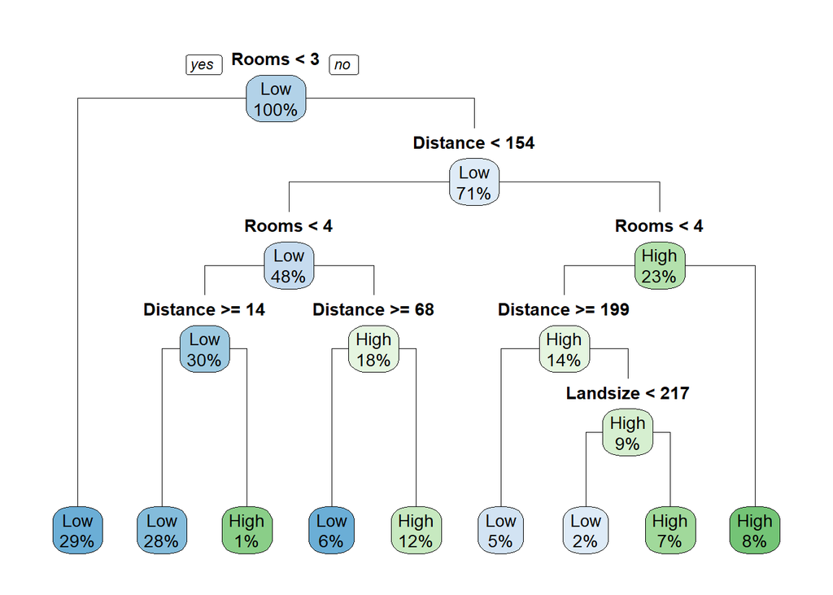

```r
set.seed(9351)
start_time_dt1 <- Sys.time()
mod1<- rpart(Price~.,training_dec_df,method = "class")
end_time_dt1 <- Sys.time()
diff_dt1<- end_time_dt1-start_time_dt1

rpart.plot(mod1, type=1, extra = 100)
```

```r
mod1
```

```
## n= 19072
##
## node), split, n, loss, yval, (yprob)
##       * denotes terminal node
##
##  1) root 19072 6994 Low (0.6332844 0.3667156)
##    2) Rooms< 2.5 5583  726 Low (0.8699624 0.1300376) *
##    3) Rooms>=2.5 13489 6268 Low (0.5353251 0.4646749)
##      6) Distance< 153.5 9132 3452 Low (0.6219886 0.3780114)
##       12) Rooms< 3.5 5639 1656 Low (0.7063309 0.2936691)
##         24) Distance>=13.5 5400 1473 Low (0.7272222 0.2727778) *
##         25) Distance< 13.5 239   56 High (0.2343096 0.7656904) *
##       13) Rooms>=3.5 3493 1697 High (0.4858288 0.5141712)
##         26) Distance>=67.5 1160  314 Low (0.7293103 0.2706897) *
##         27) Distance< 67.5 2333  851 High (0.3647664 0.6352336) *
##      7) Distance>=153.5 4357 1541 High (0.3536837 0.6463163)
##       14) Rooms< 3.5 2745 1288 High (0.4692168 0.5307832)
##         28) Distance>=198.5 936  359 Low (0.6164530 0.3835470) *
##         29) Distance< 198.5 1809  711 High (0.3930348 0.6069652)
##           58) Landsize< 216.5 438  184 Low (0.5799087 0.4200913) *
##           59) Landsize>=216.5 1371  457 High (0.3333333 0.6666667) *
##       15) Rooms>=3.5 1612  253 High (0.1569479 0.8430521) *
```

Considering only rooms, distance and property count as they are the most frequent itemsets that is used to classify Price

**Parameters:**

*Min Split*: The minimum number of values in a node that must exist before a split is attempted. In other words, if the node has two members and the minimum split is set to 5, the node will become terminal, that is, no split will be attempted.

*Max Depth*: Controls the maximum depth of the tree that will be created. It can also be described as the length of the longest path from the tree root to a leaf. The root node is considered to have a depth of 0. The Max Depth value cannot exceed 30 on a 32-bit machine.

*Min Bucket*: The minimum number of entities allowed in any leaf of the tree. The default number is one-third of the value specified for Min Split.

Building tuned model by bootstrapping with a tested cp value range of 0-0.001

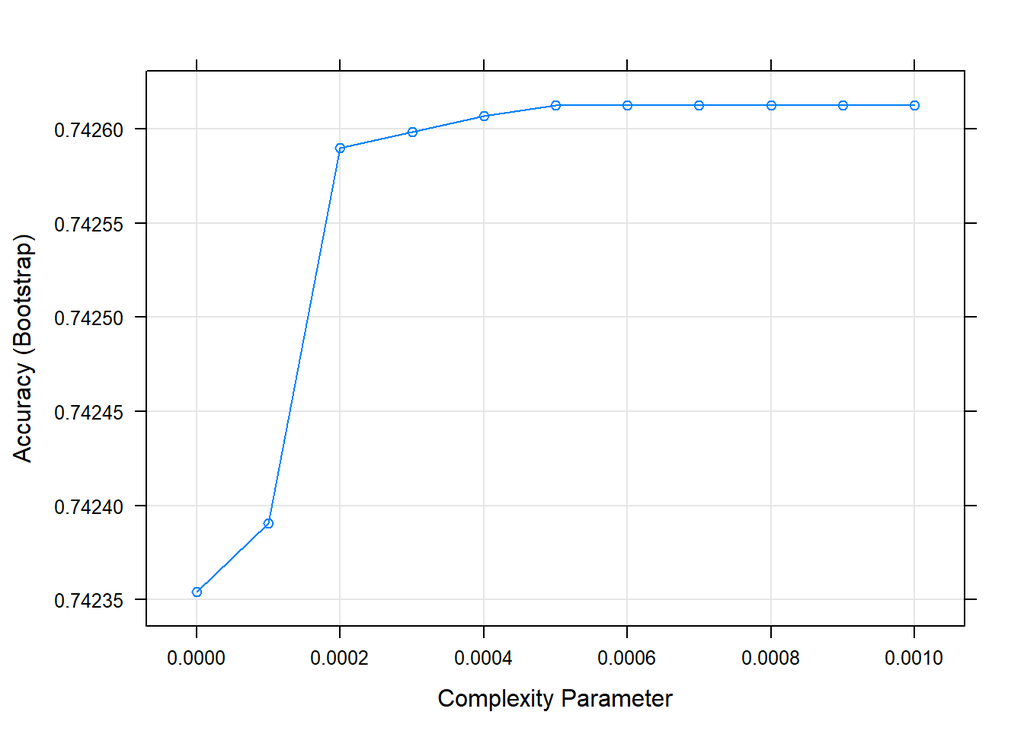

```r
training_dec_df2<- training_dec_df[,c(1,2,8,9)]
testing_dec_df2<- testing_dec_df[,c(1,2,8,9)]


set.seed(4793)
start_time_dt2 <- Sys.time()
tuned_mod<- train(Price ~ ., training_dec_df2
                  , method = 'rpart'
                  , metric = 'Accuracy'
                  , tuneLength = 100
                  , tuneGrid = expand.grid(cp = seq(0,0.001,0.0001))
                  , control = rpart.control(maxdepth = 4, minsplit = 2, minbucket = 2)
                  ,trControl = trainControl(method = 'boot', number = 50))
end_time_dt2 <- Sys.time()
diff_dt2<- end_time_dt2-start_time_dt2

plot(tuned_mod)
```

‘cp’ value of *0.0007* gave the highest accuracy for this model

Visualising the decision tree model

[figure not shown]

```r
fancyRpartPlot(tuned_mod$finalModel, main="Decision Tree", cex=0.8, tweak=0.7)
```

Interpretations:

## Modelling 5 : Naive Bayes (NB)

This is a supervised learning method for classification on categorical variables/features. It is based on Bayes Theorem by calculating posterior probability for each class and the class with highest posterior probability is outcome of prediction. P(Y|X)=(P(X|Y)xP(Y))/P(X) {independent assumption}

Running the model on default parameters

```r
set.seed(1112)
start_time_nb <- Sys.time()
def_nb <- naiveBayes(Price ~ ., data=training_dt_rf, usekernel = T)
end_time_nb <- Sys.time()
diff_nb<- end_time_nb-start_time_nb
```

Fine tuning the model (Cross-validation: 10 fold, 3 repetition)

```r
set.seed(1172)
start_time_tnb <- Sys.time()
def_tnb<- train(Price ~ ., data=training_dt_rf,method = "nb", tuneLength = 50,
                trcontrol = trainControl(method = "cv", number = 10, repeats = 3),
                tuneGrid = data.frame(fL = 1, usekernel = FALSE, adjust = 1))
end_time_tnb <- Sys.time()
diff_tnb<- end_time_tnb-start_time_tnb
```

## Modelling 6 : Logistic Regression

Logistic regression is the appropriate regression analysis to conduct when the dependent variable is dichotomous (binary). Like all regression analyses, the logistic regression is a predictive analysis. Logistic regression is used to describe data and to explain the relationship between one dependent binary variable and one or more nominal, ordinal, interval or ratio-level independent variables.

```r
lr_df<-mhp_mod[,c(2,7,9:13,16,19)]
lr_df$Distance<- as.numeric(as.factor(as.integer(lr_df$Distance)))
lr_df$Property_Count<- as.numeric(as.factor(as.integer(lr_df$Property_Count)))
lr_df[["Price"]] <- ordered(cut(lr_df[["Price"]],c(0,1050172,11300000)),labels = c("0","1"))
str(lr_df)
```

```
## 'data.frame':    27246 obs. of  9 variables:
##  $ Rooms         : num  2 2 3 3 4 2 3 2 3 2 ...
##  $ Distance      : num  82 82 82 82 82 82 82 82 82 82 ...
##  $ Bathrooms     : num  1 1 2 2 1 1 2 1 1 1 ...
##  $ Carspots      : num  1 0 0 1 2 0 0 2 2 1 ...
##  $ Landsize      : num  202 156 134 94 120 181 245 256 195 229 ...
##  $ Building_Area : num  100 79 150 110 142 92 210 107 144 80 ...
##  $ Year_Built    : num  1980 1900 1900 1970 2014 ...
##  $ Property_Count: num  186 186 186 186 186 186 186 186 186 186 ...
##  $ Price         : Ord.factor w/ 2 levels "0"<"1": 2 1 2 1 2 1 2 2 1 1 ...
```

```r
#table(lr_df$Property_Count)
set.seed(8038)
start_time_glm <- Sys.time()
def_glm <- glm(Price ~ .,family = binomial(link = "logit") ,data=lr_df)
end_time_glm <- Sys.time()
diff_glm<- end_time_glm-start_time_glm

summary(def_glm)
```

```
##
## Call:
## glm(formula = Price ~ ., family = binomial(link = "logit"), data = lr_df)
##
## Deviance Residuals:
##     Min       1Q   Median       3Q      Max
## -4.1625  -0.8396  -0.5409   0.9849   2.6290
##
## Coefficients:
##                  Estimate Std. Error z value Pr(>|z|)
## (Intercept)     2.165e+01  8.059e-01  26.861  < 2e-16 ***
## Rooms           7.392e-01  2.227e-02  33.195  < 2e-16 ***
## Distance        3.530e-03  2.073e-04  17.033  < 2e-16 ***
## Bathrooms       5.262e-01  2.780e-02  18.924  < 2e-16 ***
## Carspots        3.581e-02  1.587e-02   2.257    0.024 *
## Landsize        1.032e-06  4.778e-06   0.216    0.829
## Building_Area   1.914e-03  2.119e-04   9.035  < 2e-16 ***
## Year_Built     -1.332e-02  4.145e-04 -32.130  < 2e-16 ***
## Property_Count  7.453e-04  1.342e-04   5.552 2.82e-08 ***
## ---
## Signif. codes:  0 '***' 0.001 '**' 0.01 '*' 0.05 '.' 0.1 ' ' 1
##
## (Dispersion parameter for binomial family taken to be 1)
##
##     Null deviance: 35825  on 27245  degrees of freedom
## Residual deviance: 29730  on 27237  degrees of freedom
## AIC: 29748
##
## Number of Fisher Scoring iterations: 5
```

## Modelling 7 : Support Vector Machine (SVM)

SVM works with both linear and non-linear data(logit/sigmoid function) by maximising the margins between the categories. It is used mainly for outliers, wherein the distance between data points and decision boundary indicates confidence of prediction. Kernels are used to project linearly unseparable data points into higher dimensional space so that a hyperplane could be found to separate different classes.

Splitting the dataset into training and testing with 70% and 30%

```r
str(lr_df)
```

```
## 'data.frame':    27246 obs. of  9 variables:
##  $ Rooms         : num  2 2 3 3 4 2 3 2 3 2 ...
##  $ Distance      : num  82 82 82 82 82 82 82 82 82 82 ...
##  $ Bathrooms     : num  1 1 2 2 1 1 2 1 1 1 ...
##  $ Carspots      : num  1 0 0 1 2 0 0 2 2 1 ...
##  $ Landsize      : num  202 156 134 94 120 181 245 256 195 229 ...
##  $ Building_Area : num  100 79 150 110 142 92 210 107 144 80 ...
##  $ Year_Built    : num  1980 1900 1900 1970 2014 ...
##  $ Property_Count: num  186 186 186 186 186 186 186 186 186 186 ...
##  $ Price         : Ord.factor w/ 2 levels "0"<"1": 2 1 2 1 2 1 2 2 1 1 ...
```

```r
train_size_lr_df = floor(0.7*nrow(lr_df))
test_size_lr_df = floor(0.3*nrow(lr_df))

set.seed(9327)   # set seed to ensure you always have same random numbers generated
train_ind_lr_df = sample(seq_len(nrow(lr_df)),size = train_size_lr_df)
test_ind_lr_df = sample(seq_len(nrow(lr_df)),size = test_size_lr_df)

training_lr_df<- lr_df[train_ind_lr_df,]
testing_lr_df<- lr_df[test_ind_lr_df,]
```

*C and Gamma* are the parameters for a nonlinear support vector machine (SVM) with a Gaussian radial basis function kernel.

C is the parameter for the soft margin cost function, which controls the influence of each individual support vector; this process involves trading error penalty for stability. Gamma is the free parameter of the Gaussian radial basis function.

Cost factor value range was chosen after running against different values ranging from 0.25 to 0.5

Linear tuned SVM model with ensemble bootstrapping 5 times

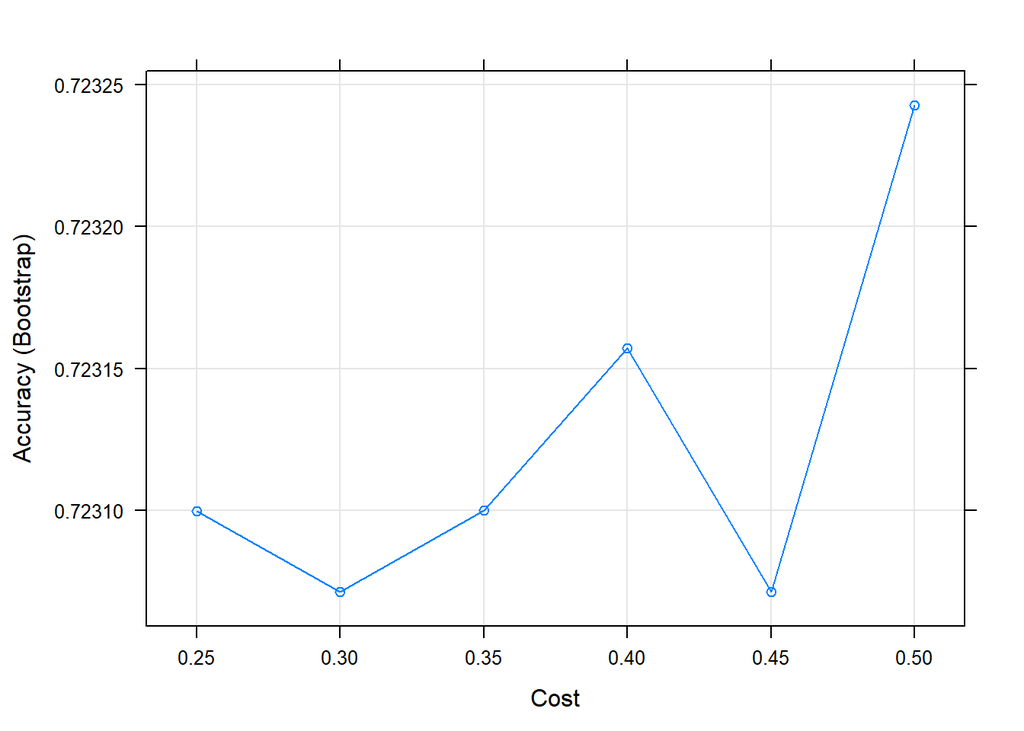

```r
set.seed(2727)
start_time_lsvm <- Sys.time()
svm_linear <- train(Price ~ ., data = training_lr_df,
                          method = "svmLinear",
                          preProcess = c("center", "scale"),
                          trControl = trainControl(method = "boot", number = 5),
                          tuneGrid = expand.grid(C = seq(0.25,0.5,0.05)))
end_time_lsvm <- Sys.time()
diff_lsvm<- end_time_lsvm-start_time_lsvm
plot(svm_linear)
```

Model

```r
svm_linear
```

```
## Support Vector Machines with Linear Kernel
##
## 19072 samples
##     8 predictor
##     2 classes: '0', '1'
##
## Pre-processing: centered (8), scaled (8)
## Resampling: Bootstrapped (5 reps)
## Summary of sample sizes: 19072, 19072, 19072, 19072, 19072
## Resampling results across tuning parameters:
##
##   C     Accuracy   Kappa
##   0.25  0.7230996  0.3593725
##   0.30  0.7230712  0.3592955
##   0.35  0.7230999  0.3593733
##   0.40  0.7231570  0.3595047
##   0.45  0.7230713  0.3593184
##   0.50  0.7232428  0.3597135
##
## Accuracy was used to select the optimal model using the largest value.
## The final value used for the model was C = 0.5.
```

Non-linear(Radial) tuned SVM model with ensemble bootstrapping 5 times

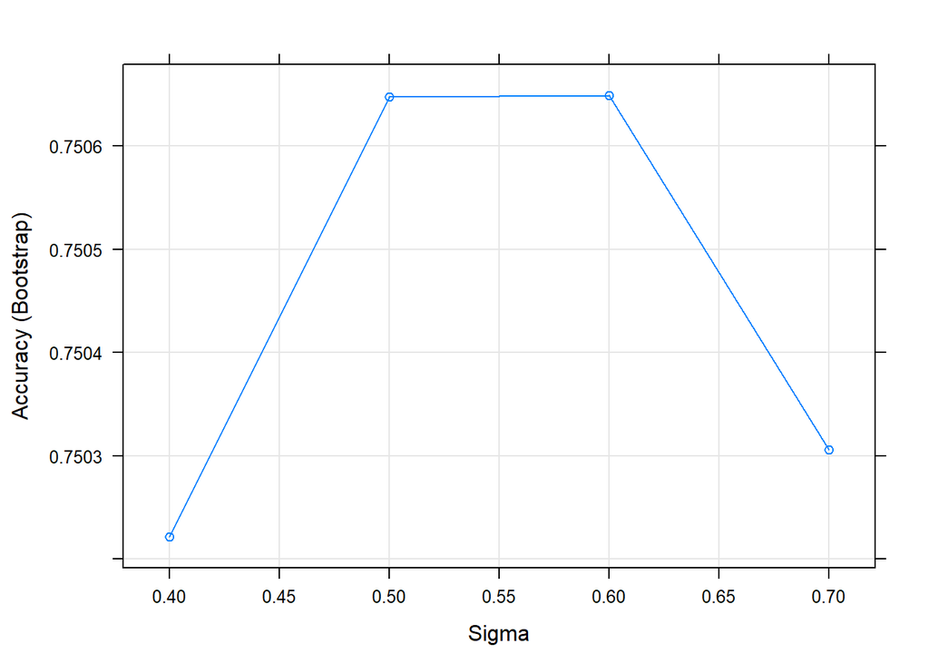

```r
set.seed(3311)
start_time_rsvm <- Sys.time()
svm_radial <- train(Price ~ ., data = training_lr_df,
                          method = "svmRadial",
                          preProcess = c("center", "scale"),
                          trControl = trainControl(method = "boot", number = 5),
                          tuneGrid = expand.grid(C = 0.3 ,sigma=seq(0.4,0.7,0.1)))
end_time_rsvm <- Sys.time()
diff_rsvm<- end_time_rsvm-start_time_rsvm
plot(svm_radial)
```

Model

```r
svm_radial
```

```
## Support Vector Machines with Radial Basis Function Kernel
##
## 19072 samples
##     8 predictor
##     2 classes: '0', '1'
##
## Pre-processing: centered (8), scaled (8)
## Resampling: Bootstrapped (5 reps)
## Summary of sample sizes: 19072, 19072, 19072, 19072, 19072
## Resampling results across tuning parameters:
##
##   sigma  Accuracy   Kappa
##   0.4    0.7502213  0.4336059
##   0.5    0.7506473  0.4360369
##   0.6    0.7506491  0.4372065
##   0.7    0.7503058  0.4371454
##
## Tuning parameter 'C' was held constant at a value of 0.3
## Accuracy was used to select the optimal model using the largest value.
## The final values used for the model were sigma = 0.6 and C = 0.3.
```

## Modelling 8 : Linear Regression

Multiple linear regression attempts to model the relationship between two or more explanatory variables and a response variable by fitting a linear equation to observed data. Every value of the independent variable x is associated with a value of the dependent variable y.

```r
lm_data<-cor_data[,-c(2)]
```

Determining the most parsimonious model based on lowest AIC value through backward elimination

```r
model_al2 <- lm(formula = Price~. ,data=lm_data)
step(model_al2, data=lm_data, direction = "backward")
```

```
## Start:  AIC=718842.2
## Price ~ Rooms + Distance + Bathrooms + Carspots + Landsize +
##     Building_Area + Year_Built + Property_Count
##
##                  Df  Sum of Sq        RSS    AIC
## <none>                         7.8196e+15 718842
## - Landsize        1 9.2870e+11 7.8205e+15 718843
## - Building_Area   1 1.6635e+12 7.8212e+15 718846
## - Property_Count  1 2.5224e+12 7.8221e+15 718849
## - Carspots        1 1.7460e+13 7.8370e+15 718901
## - Distance        1 2.0712e+14 8.0267e+15 719553
## - Year_Built      1 4.0572e+14 8.2253e+15 720218
## - Bathrooms       1 4.1902e+14 8.2386e+15 720262
## - Rooms           1 5.8899e+14 8.4086e+15 720819
```

```
##
## Call:
## lm(formula = Price ~ Rooms + Distance + Bathrooms + Carspots +
##     Landsize + Building_Area + Year_Built + Property_Count, data = lm_data)
##
## Coefficients:
##    (Intercept)           Rooms        Distance       Bathrooms
##      6.686e+06       2.066e+05       1.260e+03       2.333e+05
##       Carspots        Landsize   Building_Area      Year_Built
##      2.886e+04       1.874e+00       2.769e+01      -3.471e+03
## Property_Count
##      9.103e+01
```

Running a regression on this model;

```r
model_lowAIC <- lm(formula = Price~Rooms + Distance + Bathrooms + Carspots + Year_Built +
    Property_Count ,data=lm_data)
summary(model_lowAIC)
```

```
##
## Call:
## lm(formula = Price ~ Rooms + Distance + Bathrooms + Carspots +
##     Year_Built + Property_Count, data = lm_data)
##
## Residuals:
##      Min       1Q   Median       3Q      Max
## -3076420  -310093   -87214   199290  9774208
##
## Coefficients:
##                  Estimate Std. Error t value Pr(>|t|)
## (Intercept)    6698602.32  181930.18  36.820  < 2e-16 ***
## Rooms           207384.20    4550.27  45.576  < 2e-16 ***
## Distance          1260.86      46.93  26.867  < 2e-16 ***
## Bathrooms       234537.59    6093.28  38.491  < 2e-16 ***
## Carspots         29300.45    3698.23   7.923 2.41e-15 ***
## Year_Built       -3476.97      92.32 -37.664  < 2e-16 ***
## Property_Count      91.73      30.71   2.987  0.00282 **
## ---
## Signif. codes:  0 '***' 0.001 '**' 0.01 '*' 0.05 '.' 0.1 ' ' 1
##
## Residual standard error: 535900 on 27239 degrees of freedom
## Multiple R-squared:  0.3023, Adjusted R-squared:  0.3021
## F-statistic:  1967 on 6 and 27239 DF,  p-value: < 2.2e-16
```

```r
adjR2<- round(summary(model_lowAIC)$adj.r.squared*100,4)
```